# Aprendizado de Máquina I

### Gabriel Sanfins

#### `gabrielsanfins@id.uff.br`

### 10 KNN e árvores de classificação

# $K$ vizinhos mais próximos (KNN)

## KNN - ideia

- Relembrando: $Y = r(\mathbf{X}) + \varepsilon$
  - A relação sistemática entre $\mathbf{X}$ e $Y$ é “bem comportada”: $\mathbf{X}$’s próximos $\Rightarrow$ $Y$’s semelhantes
- Usar essa ideia para criar um estimador $g$
- “*Diga-me com quem andas e te direi quem és*”

## KNN - formalização

$$g(\mathbf{x}) = \mathrm{moda}_{i \in \mathcal{N}_{\mathbf{x}}^{(k)}} y_i,$$
onde $\mathcal{N}_{\mathbf{x}}^{(k)}$ é o conjunto dos índices das $k$ observações mais próximas de $\mathbf{x}$, ou seja,
$$\mathcal{N}_{\mathbf{x}}^{(k)} = \left\{i \in \{1, \dots, n\} ~ \left| ~ d(\mathbf{x}_i, \mathbf{x}) \leq d_{\mathbf{x}}^k \right\}\right.,$$
e $d_{\mathbf{x}}^k$ representa a distância do $k$-ésimo vizinho mais próximo de $\mathbf{x}$ para $\mathbf{x}$.

## KNN - propriedades

- Hiperparâmetro $k$ $\Rightarrow$ validação cruzada
- $k$ alto $\Rightarrow$ modelo simples
  - $k \to \infty$ $\Rightarrow$ $g$ simples (linear?)
  - Viés alto, baixa variância
- $k$ pequeno $\Rightarrow$ modelo mais complexo
  - Variância alta, viés baixo
  - Requer mais dados para ser mais fidedigno

## KNN - Exemplo

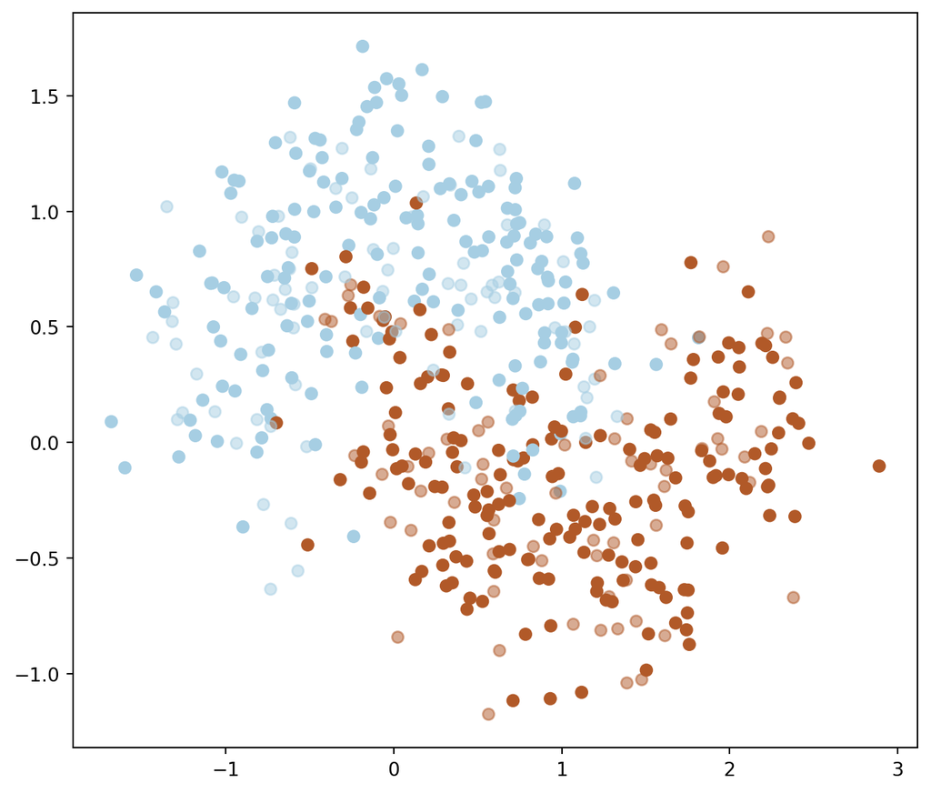

## KNN - Exemplo

scikit-learn - [KNeighborsClassifier](https://scikit-learn.org/stable/modules/generated/sklearn.neighbors.KNeighborsClassifier.html)

```python
KNN = KNeighborsClassifier(n_neighbors = 1)
KNN.fit(X_train, y_train);
```

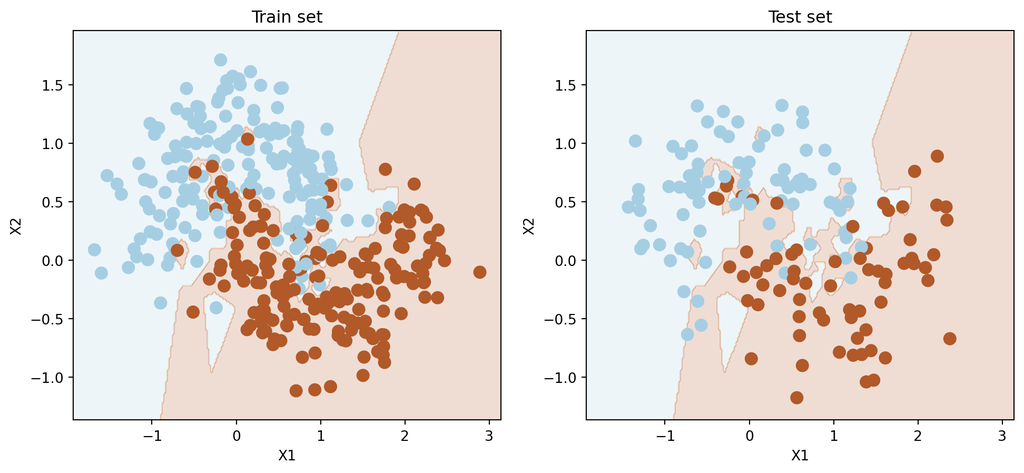

## KNN - Exemplo

```python
KNN = KNeighborsClassifier(n_neighbors = 5)
KNN.fit(X_train, y_train);
```

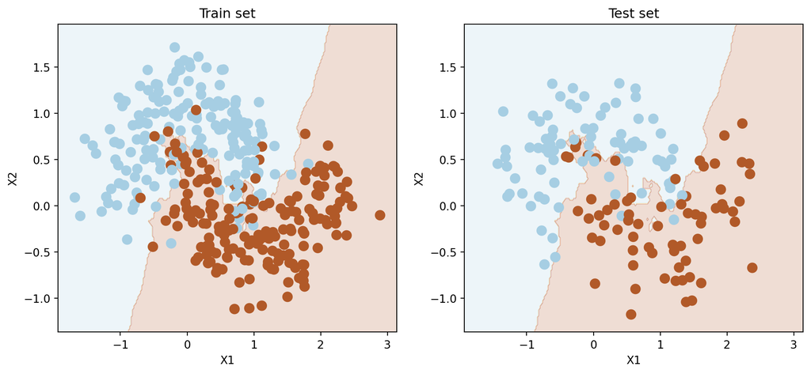

## KNN - Exemplo

```python
KNN = KNeighborsClassifier(n_neighbors = 50)
KNN.fit(X_train, y_train);
```

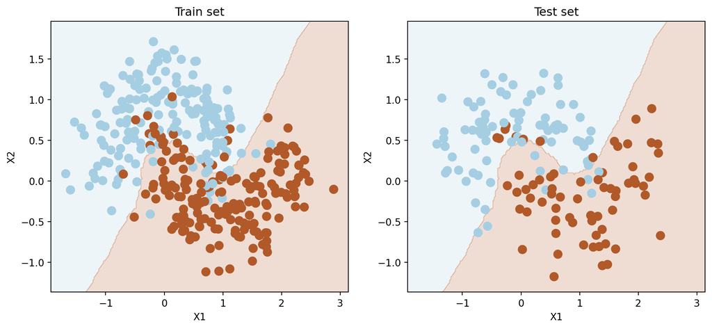

## KNN - Exemplo

```python
KNN = KNeighborsClassifier(n_neighbors = 300)
KNN.fit(X_train, y_train);
```

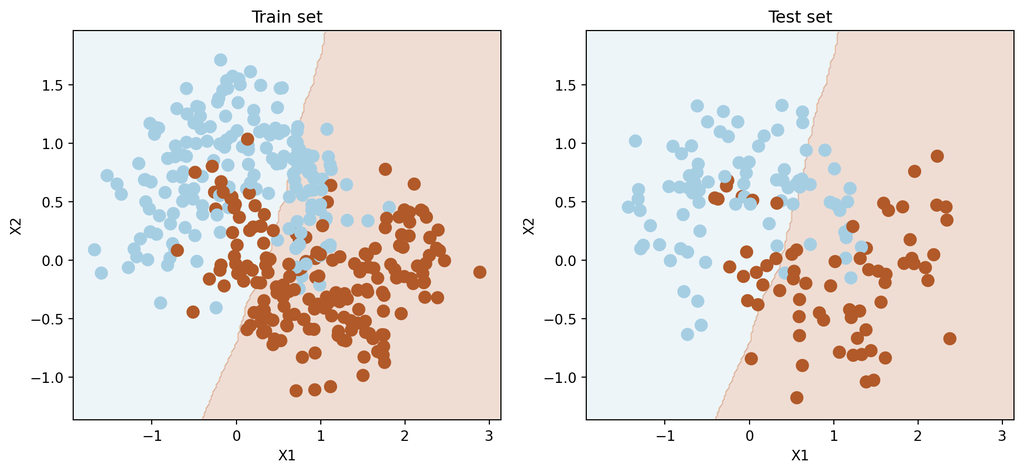

## KNN - Observações

- Hiperparâmetros podem (e devem!) ser otimizados através de validação cruzada
- Classificador naturalmente multiclasse
- Distâncias em alta dimensão podem impactar seu desempenho

# Árvores de classificação

## Formalizando

- Partição do espaço das covariáveis
  - Regiões $R_1, \dots, R_j$ distintas disjuntas
  - A predição para a resposta $Y$ de uma observação $\mathbf{x}$ que está na região $k$ é a moda das respostas cujos respectivos $\mathbf{x}$ também estão nessa região:
    $$g(\mathbf{x}) = \mathrm{moda}_{\{i ~ | ~ \mathbf{x}_i \in R_k\}} y_i$$

## Criação da árvore

- Métricas para determinar uma nova região $R$:
  - Erro de classificação: $\displaystyle E = 1 - \max_{c} \hat{p}_{R, c}$
  - Índice de Gini: $\displaystyle G = \sum_R\sum_{c \in \mathcal{C}} \hat{p}_{R, c}(1 - \hat{p}_{R, c})$
  - Entropia: $\displaystyle D = -\sum_{c \in \mathcal{C}} \hat{p}_{R, c}\log(\hat{p}_{R, c})$
- $\hat{p}_{R, c}$ é a proporção de observações classificadas como sendo da classe $c$ entre as que caem na região $R$
- Prezar por árvores *puras*: cada folha contém observações de somente uma única classe

## Árvores de classificação - Observações

- Hiperparâmetros podem (e devem!) ser otimizados através de validação cruzada
- Classificador naturalmente multiclasse
- Poda análoga a árvores de regressão
- Podem ser acopladas em *bagging*
- Podem ser acopladas em florestas aleatórias

## Árvores de classificação - Exemplo

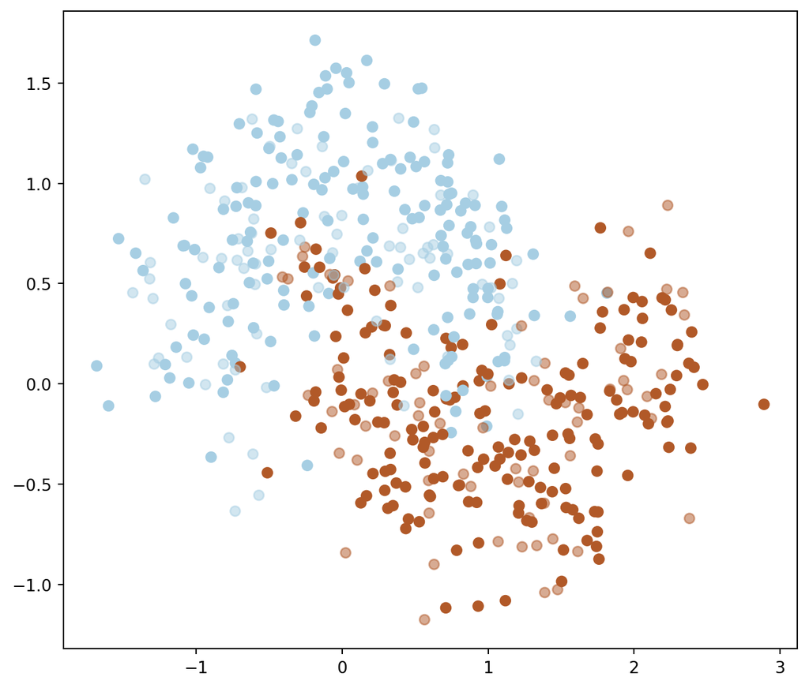

## Árvores de classificação - Exemplo

scikit-learn - [DecisionTreeClassifier](https://scikit-learn.org/stable/modules/generated/sklearn.tree.DecisionTreeClassifier.html)

```python
DTC = DecisionTreeClassifier(max_depth = None, min_samples_leaf = 5)
DTC.fit(X_train, y_train);
```

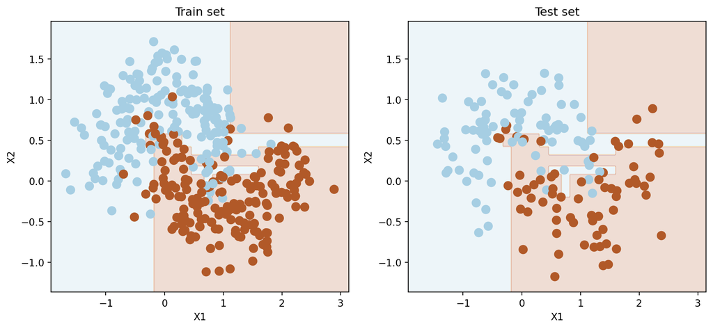